# Project: Identify Customer Segments

### Step 1.2: Select and Re-Encode Features

Checking for missing data isn't the only way in which you can prepare a dataset for analysis. Since the unsupervised learning techniques to be used will only work on data that is encoded numerically, you need to make a few encoding changes or additional assumptions to be able to make progress. In addition, while almost all of the values in the dataset are encoded using numbers, not all of them represent numeric values. Check the third column of the feature summary (`feat_info`) for a summary of types of measurement.

- For numeric and interval data, these features can be kept without changes.
- Most of the variables in the dataset are ordinal in nature. While ordinal values may technically be non-linear in spacing, make the simplifying assumption that the ordinal variables can be treated as being interval in nature (that is, kept without any changes).
- Special handling may be necessary for the remaining two variable types: categorical, and 'mixed'.

In the first two parts of this sub-step, you will perform an investigation of the categorical and mixed-type features and make a decision on each of them, whether you will keep, drop, or re-encode each. Then, in the last part, you will create a new data frame with only the selected and engineered columns.

Data wrangling is often the trickiest part of the data analysis process, and there's a lot of it to be done here. But stick with it: once you're done with this step, you'll be ready to get to the machine learning parts of the project!

```python
#copy dataset
azdias_clean = azdias_ln.copy()
```

```python
#Remove dropped columns from feat_info
features = list(azdias_ln.columns)
feat_info_clean = feat_info.copy()
feat_info_clean = feat_info_clean[feat_info_clean['attribute'].isin(features)]
feat_info_clean.info()
```

```
<class 'pandas.core.frame.DataFrame'>
Int64Index: 79 entries, 1 to 84
Data columns (total 4 columns):
attribute             79 non-null object
information_level     79 non-null object
type                  79 non-null object
missing_or_unknown    79 non-null object
dtypes: object(4)
memory usage: 3.1+ KB
```

```python
# How many features are there of each data type?
feat_info_clean.type.value_counts()
```

```
ordinal        49
categorical    18
numeric         6
mixed           6
Name: type, dtype: int64
```

#### Step 1.2.1: Re-Encode Categorical Features

For categorical data, you would ordinarily need to encode the levels as dummy variables. Depending on the number of categories, perform one of the following:

- For binary (two-level) categoricals that take numeric values, you can keep them without needing to do anything.
- There is one binary variable that takes on non-numeric values. For this one, you need to re-encode the values as numbers or create a dummy variable.
- For multi-level categoricals (three or more values), you can choose to encode the values using multiple dummy variables (e.g. via [OneHotEncoder](http://scikit-learn.org/stable/modules/generated/sklearn.preprocessing.OneHotEncoder.html)), or (to keep things straightforward) just drop them from the analysis. As always, document your choices in the Discussion section.

```python
# Assess categorical variables: which are binary, which are multi-level, and
# which one needs to be re-encoded?
cat_features = feat_info_clean[feat_info_clean['type'] == 'categorical']['attribute']
cat_features
```

```
2            ANREDE_KZ
3        CJT_GESAMTTYP
10           FINANZTYP
12     GFK_URLAUBERTYP
13    GREEN_AVANTGARDE
17     LP_FAMILIE_FEIN
18     LP_FAMILIE_GROB
19      LP_STATUS_FEIN
20      LP_STATUS_GROB
21    NATIONALITAET_KZ
38         SHOPPER_TYP
39             SOHO_KZ
41            VERS_TYP
42            ZABEOTYP
52         GEBAEUDETYP
55         OST_WEST_KZ
57     CAMEO_DEUG_2015
58      CAMEO_DEU_2015
Name: attribute, dtype: object
```

```python
# Re-encode categorical variable(s) to be kept in the analysis.
binary_features = []
multilevel_features = []

for col in cat_features:
    if azdias_clean[col].nunique() == 2:
        binary_features.append(col)
    else:
        multilevel_features.append(col)
```

```python
print("Binary features are: {}.".format(binary_features))
for col in binary_features:
    print("The values of {} are {}.".format(col, azdias_clean[col].unique()))
```

```
Binary features are: ['ANREDE_KZ', 'GREEN_AVANTGARDE', 'SOHO_KZ', 'VERS_TYP', 'OST_WEST_KZ'].
The values of ANREDE_KZ are [2 1].
The values of GREEN_AVANTGARDE are [0 1].
The values of SOHO_KZ are [ 1.  0.].
The values of VERS_TYP are [  2.   1.  nan].
The values of OST_WEST_KZ are ['W' 'O'].
```

Except for GREEN_AVANTGARDE and SOHO_KZ, all binary features must be re-encoded.

```python
#Recode Gender into 0 = Male, 1 = Female
azdias_clean.rename(columns={"ANREDE_KZ":"GENDER"}, inplace=True)
azdias_clean['GENDER'] = azdias_clean['GENDER']-1
azdias_clean['GENDER'].unique()
```

```
array([1, 0])
```

```python
#Recode VERS_TYP into ints of 0 and 1, with 1 as "individualistic / accepting risks"
azdias_clean['VERS_TYP'] = azdias_clean['VERS_TYP']-1
azdias_clean.VERS_TYP.unique()
```

```
array([  1.,   0.,  nan])
```

```python
#Recode OST_WEST_KZ into 0 and 1, rename into "IN_EAST"
location = {'O': 1,'W': 0}
azdias_clean.OST_WEST_KZ = [location[item] for item in azdias_clean.OST_WEST_KZ]
azdias_clean.rename(columns={"OST_WEST_KZ":"IN_EAST"}, inplace=True)
azdias_clean.IN_EAST.unique()
```

```
array([0, 1])
```

```python
print("Multilevel Categorical Featuers are: {}.".format(multilevel_features))
for col in multilevel_features:
    print("The values of {} are {}.".format(col, azdias_clean[col].unique()))
```

```
Multilevel Categorical Featuers are: ['CJT_GESAMTTYP', 'FINANZTYP', 'GFK_URLAUBERTYP', 'LP_FAMILIE_FEIN', 'LP_FAMILIE_GROB', 'LP_STATUS_FEIN', 'LP_STATUS_GROB', 'NATIONALITAET_KZ', 'SHOPPER_TYP', 'ZABEOTYP', 'GEBAEUDETYP', 'CAMEO_DEUG_2015', 'CAMEO_DEU_2015'].
The values of CJT_GESAMTTYP are [  5.   3.   2.   4.   1.   6.  nan].
The values of FINANZTYP are [1 6 5 2 4 3].
The values of GFK_URLAUBERTYP are [ 10.   1.   5.  12.   9.   3.   8.  11.   4.   2.   7.   6.  nan].
The values of LP_FAMILIE_FEIN are [  5.   1.  nan  10.   2.   7.  11.   8.   4.   6.   9.   3.].
The values of LP_FAMILIE_GROB are [  3.   1.  nan   5.   2.   4.].
The values of LP_STATUS_FEIN are [  2.   3.   9.   4.   1.  10.   5.   8.   6.   7.  nan].
The values of LP_STATUS_GROB are [  1.   2.   4.   5.   3.  nan].
The values of NATIONALITAET_KZ are [  1.   3.   2.  nan].
The values of SHOPPER_TYP are [  3.   2.   1.   0.  nan].
The values of ZABEOTYP are [5 3 4 1 6 2].
The values of GEBAEUDETYP are [ 8.  1.  3.  2.  6.  4.  5.].
The values of CAMEO_DEUG_2015 are ['8' '4' '2' '6' '1' '9' '5' '7' nan '3'].
The values of CAMEO_DEU_2015 are ['8A' '4C' '2A' '6B' '8C' '4A' '2D' '1A' '1E' '9D' '5C' '8B' '7A' '5D' '9E'
 nan '9B' '1B' '3D' '4E' '4B' '3C' '5A' '7B' '9A' '6D' '6E' '2C' '7C' '9C'
 '7D' '5E' '1D' '8D' '6C' '6A' '5B' '4D' '3A' '2B' '7E' '3B' '6F' '5F' '1C'].
```

Looking at the information provided in DataDictionary_md, I have decided to drop the variables LP_FAMILIE_FEIN, LP_STATUS_FEIN, CAMEO_DEUG_2015 and CAMEO_DEU_2015, as they contain very specific information, that is captured on a more fitting level in the features LP_FAMILIE_GROB, LP_STATUS_GROB and in the later recoded mixed features CAMEO_INTL_2015.

```python
remove_cols = ['LP_FAMILIE_FEIN', 'CAMEO_DEU_2015', 'CAMEO_DEUG_2015','LP_STATUS_FEIN']
azdias_clean = azdias_clean.drop(remove_cols, axis=1)
```

```python
for col in remove_cols:
    multilevel_features.remove(col)
multilevel_features
```

```
['CJT_GESAMTTYP',
 'FINANZTYP',
 'GFK_URLAUBERTYP',
 'LP_FAMILIE_GROB',
 'LP_STATUS_GROB',
 'NATIONALITAET_KZ',
 'SHOPPER_TYP',
 'ZABEOTYP',
 'GEBAEUDETYP']
```

```python
azdias_clean = pd.get_dummies(azdias_clean, columns = multilevel_features)
```

```python
print(list(azdias_clean.columns))
```

```
['ALTERSKATEGORIE_GROB', 'GENDER', 'FINANZ_MINIMALIST', 'FINANZ_SPARER', 'FINANZ_VORSORGER', 'FINANZ_ANLEGER', 'FINANZ_UNAUFFAELLIGER', 'FINANZ_HAUSBAUER', 'GREEN_AVANTGARDE', 'HEALTH_TYP', 'LP_LEBENSPHASE_FEIN', 'LP_LEBENSPHASE_GROB', 'PRAEGENDE_JUGENDJAHRE', 'RETOURTYP_BK_S', 'SEMIO_SOZ', 'SEMIO_F…
```

#### Discussion 1.2.1: Re-Encode Categorical Features

I kept all of the binary variables, recoding them into 0 and 1. As for the multilevel categorical features, I dropped redundant variables ('LP_FAMILIE_FEIN', 'CAMEO_DEU_2015', 'CAMEO_DEUG_2015, 'LP_STATUS_FEIN') and recoded the rest into Dummies.

#### Step 1.2.2: Engineer Mixed-Type Features

There are a handful of features that are marked as "mixed" in the feature summary that require special treatment in order to be included in the analysis. There are two in particular that deserve attention; the handling of the rest are up to your own choices:

- "PRAEGENDE_JUGENDJAHRE" combines information on three dimensions: generation by decade, movement (mainstream vs. avantgarde), and nation (east vs. west). While there aren't enough levels to disentangle east from west, you should create two new variables to capture the other two dimensions: an interval-type variable for decade, and a binary variable for movement.
- "CAMEO_INTL_2015" combines information on two axes: wealth and life stage. Break up the two-digit codes by their 'tens'-place and 'ones'-place digits into two new ordinal variables (which, for the purposes of this project, is equivalent to just treating them as their raw numeric values).
- If you decide to keep or engineer new features around the other mixed-type features, make sure you note your steps in the Discussion section.

Be sure to check `Data_Dictionary.md` for the details needed to finish these tasks.

```python
mixed_features = feat_info_clean[feat_info_clean['type'] == 'mixed']['attribute']
mixed_features
```

```
15      LP_LEBENSPHASE_FEIN
16      LP_LEBENSPHASE_GROB
22    PRAEGENDE_JUGENDJAHRE
56                 WOHNLAGE
59          CAMEO_INTL_2015
79              PLZ8_BAUMAX
Name: attribute, dtype: object
```

```python
# Investigate "PRAEGENDE_JUGENDJAHRE" and engineer two new variables.
azdias_clean['DECADE'] = azdias_clean['PRAEGENDE_JUGENDJAHRE']
azdias_clean['MOVEMENT'] = azdias_clean['PRAEGENDE_JUGENDJAHRE']
```

```python
#mapping values to their codes by dictionaries
movement_dict = {1:0, 2:1, 3:0, 4:1, 5:0, 6:1, 7:1, 8:0, 9:1, 10:0, 11:1, 12:0, 13:1, 14:0, 15:1}
decade_dict = {1:1, 2:1, 3:2, 4:2, 5:3, 6:3, 7:3, 8:4, 9:4, 10:5, 11:5, 12:5, 13:5, 14:6, 15:6}
```

```python
azdias_clean['DECADE'].replace(decade_dict, inplace=True)
azdias_clean['MOVEMENT'].replace(movement_dict, inplace=True)
```

```python
print(azdias_clean.DECADE.unique())
print(azdias_clean.MOVEMENT.unique())
```

```
[  6.   4.   2.   5.   3.  nan   1.]
[  0.   1.  nan]
```

```python
# Investigate "CAMEO_INTL_2015" and engineer two new variables.
azdias_clean['WEALTH'] = azdias_clean['CAMEO_INTL_2015']
azdias_clean['LIFE_STAGE'] = azdias_clean['CAMEO_INTL_2015']
```

```python
wealth_dict = {'11':1, '12':1, '13':1, '14':1, '15':1, '21':2, '22':2, '23':2, '24':2, '25':2,
               '31':3, '32':3, '33':3, '34':3, '35':3, '41':4, '42':4, '43':4, '44':4, '45':4,
               '51':5, '52':5, '53':5, '54':5, '55':5}
life_stage_dict = {'11':1, '12':2, '13':3, '14':4, '15':5, '21':1, '22':2, '23':3, '24':4, '25':5,
                   '31':1, '32':2, '33':3, '34':4, '35':5, '41':1, '42':2, '43':3, '44':4, '45':5,
                   '51':1, '52':2, '53':3, '54':4, '55':5}
```

```python
azdias_clean['WEALTH'].replace(wealth_dict, inplace=True)
azdias_clean['LIFE_STAGE'].replace(life_stage_dict, inplace=True)
```

```python
print(azdias_clean.WEALTH.unique())
print(azdias_clean.LIFE_STAGE.unique())
```

```
[  5.   2.   1.   4.   3.  nan]
[  1.   4.   2.   3.   5.  nan]
```

```python
azdias_clean = azdias_clean.drop(mixed_features, axis=1)
print(list(azdias_clean.columns))
```

```
['ALTERSKATEGORIE_GROB', 'GENDER', 'FINANZ_MINIMALIST', 'FINANZ_SPARER', 'FINANZ_VORSORGER', 'FINANZ_ANLEGER', 'FINANZ_UNAUFFAELLIGER', 'FINANZ_HAUSBAUER', 'GREEN_AVANTGARDE', 'HEALTH_TYP', 'RETOURTYP_BK_S', 'SEMIO_SOZ', 'SEMIO_FAM', 'SEMIO_REL', 'SEMIO_MAT', 'SEMIO_VERT', 'SEMIO_LUST', 'SEMIO_ERL',…
```

#### Discussion 1.2.2: Engineer Mixed-Type Features

I created two new variables from the mixed type "PRAEGENDE_JUGENDJAHRE" - one binary variable on which movement the individual belonged to and one interval variable concerning decades.  
I also created two variables out of "CAMEO_INTL_2015", concerning wealth (ordinal - 1 to 5) and life stage (ordinal - 1 to 5).  
I then dropped all remaining mixed type features, as they contain independent information and thus are not interpretable in their original form.

#### Step 1.2.3: Complete Feature Selection

In order to finish this step up, you need to make sure that your data frame now only has the columns that you want to keep. To summarize, the dataframe should consist of the following:

- All numeric, interval, and ordinal type columns from the original dataset.
- Binary categorical features (all numerically-encoded).
- Engineered features from other multi-level categorical features and mixed features.

Make sure that for any new columns that you have engineered, that you've excluded the original columns from the final dataset. Otherwise, their values will interfere with the analysis later on the project. For example, you should not keep "PRAEGENDE_JUGENDJAHRE", since its values won't be useful for the algorithm: only the values derived from it in the engineered features you created should be retained. As a reminder, your data should only be from **the subset with few or no missing values**.

```python
# If there are other re-engineering tasks you need to perform, make sure you
# take care of them here. (Dealing with missing data will come in step 2.1.)
```

```python
# Do whatever you need to in order to ensure that the dataframe only contains
# the columns that should be passed to the algorithm functions.
```

### Step 1.3: Create a Cleaning Function

Even though you've finished cleaning up the general population demographics data, it's important to look ahead to the future and realize that you'll need to perform the same cleaning steps on the customer demographics data. In this substep, complete the function below to execute the main feature selection, encoding, and re-engineering steps you performed above. Then, when it comes to looking at the customer data in Step 3, you can just run this function on that DataFrame to get the trimmed dataset in a single step.

```python
def clean_data(df):
    """
    Perform feature trimming, re-encoding, and engineering for demographics
    data

    INPUT: Demographics DataFrame
    OUTPUT: Trimmed and cleaned demographics DataFrame
    """

    # Put in code here to execute all main cleaning steps:
    # convert missing value codes into NaNs, ...
    nan_list=[]
    df_clean = df.copy()
    for idx in range(len(feat_info)):
        nans = feat_info.iloc[idx]['missing_or_unknown']
        nans = nans.strip('[').strip(']').split(sep=',')
        nans = [int(value) if (value!='X' and value!='XX' and value!='') else value for value in nans]
        nan_list.append(nans)
    for idx in range(len(feat_info)):
        col = feat_info.iloc[idx]['attribute']
        df_clean[col].replace(to_replace=nan_list[idx], value=np.nan, inplace=True)

    #Clean identified Columns
    columns_over_200K = ['AGER_TYP', 'GEBURTSJAHR', 'TITEL_KZ', 'ALTER_HH', 'KK_KUNDENTYP', 'KBA05_BAUMAX']
    df_clean = df_clean.drop(columns_over_200K, axis=1)

    #re-encode binaries
    df_clean.rename(columns={"ANREDE_KZ":"GENDER"}, inplace=True)
    df_clean['GENDER'] = df_clean['GENDER']-1
    df_clean['VERS_TYP'] = df_clean['VERS_TYP']-1
    location = {'O': 1,'W': 0, np.nan:np.nan}
    df_clean.OST_WEST_KZ = [location[item] for item in df_clean.OST_WEST_KZ]
    df_clean.rename(columns={"OST_WEST_KZ":"IN_EAST"}, inplace=True)

    #get dummies
    categorical_drops = ['LP_FAMILIE_FEIN', 'CAMEO_DEU_2015', 'CAMEO_DEUG_2015','LP_STATUS_FEIN']

    df_clean = df_clean.drop(categorical_drops, axis=1)
    dummy_features = ['CJT_GESAMTTYP','FINANZTYP','GFK_URLAUBERTYP','LP_FAMILIE_GROB','LP_STATUS_GROB','NATIONALITAET_KZ',
                      'SHOPPER_TYP','ZABEOTYP','GEBAEUDETYP']
    df_clean = pd.get_dummies(df_clean, columns = dummy_features)

    #Clean Rows after creating Dummies to stabilize them
    df_clean = df_clean[df_clean.isnull().sum(axis=1) < 30]

    # re-encode mixed features
    df_clean['DECADE'] = df_clean['PRAEGENDE_JUGENDJAHRE']
    df_clean['MOVEMENT'] = df_clean['PRAEGENDE_JUGENDJAHRE']
    df_clean['WEALTH'] = df_clean['CAMEO_INTL_2015']
    df_clean['LIFE_STAGE'] = df_clean['CAMEO_INTL_2015']
    movement_dict = {1:0, 2:1, 3:0, 4:1, 5:0, 6:1, 7:1, 8:0, 9:1, 10:0, 11:1, 12:0, 13:1, 14:0, 15:1}
    decade_dict = {1:1, 2:1, 3:2, 4:2, 5:3, 6:3, 7:3, 8:4, 9:4, 10:5, 11:5, 12:5, 13:5, 14:6, 15:6}
    wealth_dict = {'11':1, '12':1, '13':1, '14':1, '15':1, '21':2, '22':2, '23':2, '24':2, '25':2,
                   '31':3, '32':3, '33':3, '34':3, '35':3, '41':4, '42':4, '43':4, '44':4, '45':4,
                   '51':5, '52':5, '53':5, '54':5, '55':5}
    life_stage_dict = {'11':1, '12':2, '13':3, '14':4, '15':5, '21':1, '22':2, '23':3, '24':4, '25':5,
                       '31':1, '32':2, '33':3, '34':4, '35':5, '41':1, '42':2, '43':3, '44':4, '45':5,
                       '51':1, '52':2, '53':3, '54':4, '55':5}
    df_clean['DECADE'].replace(decade_dict, inplace=True)
    df_clean['MOVEMENT'].replace(movement_dict, inplace=True)
    df_clean['WEALTH'].replace(wealth_dict, inplace=True)
    df_clean['LIFE_STAGE'].replace(life_stage_dict, inplace=True)

    #drop remaining mixed vars
    mixed_drops = ['LP_LEBENSPHASE_FEIN','LP_LEBENSPHASE_GROB','PRAEGENDE_JUGENDJAHRE','WOHNLAGE','CAMEO_INTL_2015','PLZ8_BAUMAX']
    df_clean = df_clean.drop(mixed_drops, axis=1)




    # Return the cleaned dataframe.
    return df_clean
```

## Step 2: Feature Transformation

### Step 2.1: Apply Feature Scaling

Before we apply dimensionality reduction techniques to the data, we need to perform feature scaling so that the principal component vectors are not influenced by the natural differences in scale for features. Starting from this part of the project, you'll want to keep an eye on the [API reference page for sklearn](http://scikit-learn.org/stable/modules/classes.html) to help you navigate to all of the classes and functions that you'll need. In this substep, you'll need to check the following:

- sklearn requires that data not have missing values in order for its estimators to work properly. So, before applying the scaler to your data, make sure that you've cleaned the DataFrame of the remaining missing values. This can be as simple as just removing all data points with missing data, or applying an [Imputer](http://scikit-learn.org/stable/modules/generated/sklearn.preprocessing.Imputer.html) to replace all missing values. You might also try a more complicated procedure where you temporarily remove missing values in order to compute the scaling parameters before re-introducing those missing values and applying imputation. Think about how much missing data you have and what possible effects each approach might have on your analysis, and justify your decision in the discussion section below.
- For the actual scaling function, a [StandardScaler](http://scikit-learn.org/stable/modules/generated/sklearn.preprocessing.StandardScaler.html) instance is suggested, scaling each feature to mean 0 and standard deviation 1.
- For these classes, you can make use of the `.fit_transform()` method to both fit a procedure to the data as well as apply the transformation to the data at the same time. Don't forget to keep the fit sklearn objects handy, since you'll be applying them to the customer demographics data towards the end of the project.

```python
#Print which columns include missing values
nans_col = azdias_clean.isnull().sum()
nans_col = nans_col[nans_col > 0]
nans_col
```

```
ALTERSKATEGORIE_GROB     2803
HEALTH_TYP              36721
RETOURTYP_BK_S           4745
VERS_TYP                36721
W_KEIT_KIND_HH          59302
ANZ_HAUSHALTE_AKTIV      6460
ANZ_HH_TITEL             3857
KONSUMNAEHE                71
KBA05_ANTG1             40164
KBA05_ANTG2             40164
KBA05_ANTG3             40164
KBA05_ANTG4             40164
KBA05_GBZ               40164
BALLRAUM                  592
EWDICHTE                  592
INNENSTADT                592
GEBAEUDETYP_RASTER          7
KKK                     64906
MOBI_REGIO              40164
ONLINE_AFFINITAET        4745
REGIOTYP                64906
KBA13_ANZAHL_PKW        12641
PLZ8_ANTG1              23355
PLZ8_ANTG2              23355
PLZ8_ANTG3              23355
PLZ8_ANTG4              23355
PLZ8_HHZ                23355
PLZ8_GBZ                23355
ARBEIT                   4227
ORTSGR_KLS9              4126
RELAT_AB                 4227
DECADE                  28755
MOVEMENT                28755
WEALTH                   6198
LIFE_STAGE               6198
dtype: int64
```

```python
#print names of columns with ordinal data that contain missings
ordinals= list(feat_info_clean[feat_info_clean['type']=="ordinal"]['attribute'])
ordinal_nans = list(set(ordinals) & set(nans_col.index))
ordinal_nans
```

```
['PLZ8_ANTG2',
 'KBA05_ANTG4',
 'INNENSTADT',
 'GEBAEUDETYP_RASTER',
 'RETOURTYP_BK_S',
 'ORTSGR_KLS9',
 'ONLINE_AFFINITAET',
 'KBA05_GBZ',
 'PLZ8_HHZ',
 'REGIOTYP',
 'KBA05_ANTG2',
 'KONSUMNAEHE',
 'W_KEIT_KIND_HH',
 'PLZ8_ANTG4',
 'PLZ8_GBZ',
 'EWDICHTE',
 'MOBI_REGIO',
 'KKK',
 'KBA05_ANTG1',
 'PLZ8_ANTG3',
 'ARBEIT',
 'HEALTH_TYP',
 'BALLRAUM',
 'ALTERSKATEGORIE_GROB',
 'PLZ8_ANTG1',
 'KBA05_ANTG3',
 'RELAT_AB']
```

```python
#print names of columns with numeric data that contain missings
numerics= list(feat_info_clean[feat_info_clean['type']=="numeric"]['attribute'])
numeric_nans = list(set(numerics) & set(nans_col.index))
numeric_nans
```

```
['KBA13_ANZAHL_PKW', 'ANZ_HH_TITEL', 'ANZ_HAUSHALTE_AKTIV']
```

```python
#combine numeric and ordinal columns with missings
nan_nums = ordinal_nans + numeric_nans
nan_nums
```

```
['PLZ8_ANTG2',
 'KBA05_ANTG4',
 'INNENSTADT',
 'GEBAEUDETYP_RASTER',
 'RETOURTYP_BK_S',
 'ORTSGR_KLS9',
 'ONLINE_AFFINITAET',
 'KBA05_GBZ',
 'PLZ8_HHZ',
 'REGIOTYP',
 'KBA05_ANTG2',
 'KONSUMNAEHE',
 'W_KEIT_KIND_HH',
 'PLZ8_ANTG4',
 'PLZ8_GBZ',
 'EWDICHTE',
 'MOBI_REGIO',
 'KKK',
 'KBA05_ANTG1',
 'PLZ8_ANTG3',
 'ARBEIT',
 'HEALTH_TYP',
 'BALLRAUM',
 'ALTERSKATEGORIE_GROB',
 'PLZ8_ANTG1',
 'KBA05_ANTG3',
 'RELAT_AB',
 'KBA13_ANZAHL_PKW',
 'ANZ_HH_TITEL',
 'ANZ_HAUSHALTE_AKTIV']
```

The Columns with Missing Values include both categorical, ordinal and a few numeric values. The imputing strategies will be 'most_frequent' for categorical and 'median' for ordinal and numerics, respectively. In order to instantiate the respective imputing strategies, I will separate the columns with numerical and ordinal missings from the other columns.

```python
#Create a separate dataframe for numerics with missings
azdias_clean_nums = azdias_clean[nan_nums]
azdias_clean_nums.head()
```

|  | PLZ8_ANTG2 | KBA05_ANTG4 | INNENSTADT | GEBAEUDETYP_RASTER | RETOURTYP_BK_S | ORTSGR_KLS9 | ONLINE_AFFINITAET | KBA05_GBZ | PLZ8_HHZ | REGIOTYP | KBA05_ANTG2 | KONSUMNAEHE | W_KEIT_KIND_HH | PLZ8_ANTG4 | PLZ8_GBZ | EWDICHTE | MOBI_REGIO | KKK | KBA05_ANTG1 | PLZ8_ANTG3 | ARBEIT | HEALTH_TYP | BALLRAUM | ALTERSKATEGORIE_GROB | PLZ8_ANTG1 | KBA05_ANTG3 | RELAT_AB | KBA13_ANZAHL_PKW | ANZ_HH_TITEL | … |
| --- | --- | --- | --- | --- | --- | --- | --- | --- | --- | --- | --- | --- | --- | --- | --- | --- | --- | --- | --- | --- | --- | --- | --- | --- | --- | --- | --- | --- | --- | --- |
| 1 | 3.0 | 2.0 | 8.0 | 3.0 | 1.0 | 5.0 | 3.0 | 1.0 | 5.0 | 3.0 | 0.0 | 1.0 | 3.0 | 1.0 | 4.0 | 3.0 | 1.0 | 2.0 | 0.0 | 2.0 | 3.0 | 3.0 | 6.0 | 1.0 | 2.0 | 0.0 | 4.0 | 963.0 | 0.0 | … |
| 2 | 3.0 | 0.0 | 4.0 | 4.0 | 3.0 | 5.0 | 2.0 | 3.0 | 4.0 | 2.0 | 3.0 | 5.0 | 3.0 | 0.0 | 4.0 | 4.0 | 3.0 | 2.0 | 1.0 | 1.0 | 3.0 | 3.0 | 2.0 | 3.0 | 3.0 | 1.0 | 2.0 | 712.0 | 0.0 | … |
| 3 | 2.0 | 0.0 | 6.0 | 4.0 | 2.0 | 3.0 | 1.0 | 4.0 | 3.0 | NaN | 1.0 | 4.0 | NaN | 0.0 | 4.0 | 2.0 | 4.0 | NaN | 4.0 | 2.0 | 2.0 | 2.0 | 4.0 | 4.0 | 2.0 | 0.0 | 3.0 | 596.0 | 0.0 | … |
| 4 | 4.0 | 0.0 | 1.0 | 5.0 | 5.0 | 6.0 | 5.0 | 3.0 | 3.0 | 5.0 | 4.0 | 4.0 | 2.0 | 1.0 | 3.0 | 5.0 | 3.0 | 3.0 | 1.0 | 2.0 | 4.0 | 3.0 | 2.0 | 3.0 | 2.0 | 1.0 | 5.0 | 435.0 | 0.0 | … |
| 5 | 3.0 | 0.0 | 7.0 | 4.0 | 3.0 | 3.0 | 1.0 | 4.0 | 5.0 | 5.0 | 2.0 | 5.0 | 6.0 | 1.0 | 5.0 | 2.0 | 4.0 | 4.0 | 2.0 | 1.0 | 2.0 | 3.0 | 6.0 | 1.0 | 2.0 | 0.0 | 3.0 | 1300.0 | 0.0 | … |

```python
#Impute numerics with median
fill_missing_median = Imputer(strategy='median')
azdias_clean_nums_imputed = pd.DataFrame(fill_missing_median.fit_transform(azdias_clean_nums))
azdias_clean_nums_imputed.columns = azdias_clean_nums.columns
azdias_clean_nums_imputed.index = azdias_clean_nums.index
```

```python
#Check if it worked
azdias_clean_nums_imputed.isnull().sum().sum()
```

```
0
```

```python
#Create a dataframe for the rest of the columns
azdias_clean_cats = azdias_clean.drop(nan_nums, axis=1)
azdias_clean_cats.head()
```

|  | GENDER | FINANZ_MINIMALIST | FINANZ_SPARER | FINANZ_VORSORGER | FINANZ_ANLEGER | FINANZ_UNAUFFAELLIGER | FINANZ_HAUSBAUER | GREEN_AVANTGARDE | SEMIO_SOZ | SEMIO_FAM | SEMIO_REL | SEMIO_MAT | SEMIO_VERT | SEMIO_LUST | SEMIO_ERL | SEMIO_KULT | SEMIO_RAT | SEMIO_KRIT | SEMIO_DOM | SEMIO_KAEM | SEMIO_PFLICHT | SEMIO_TRADV | SOHO_KZ | VERS_TYP | ANZ_PERSONEN | ANZ_TITEL | HH_EINKOMMEN_SCORE | WOHNDAUER_2008 | MIN_GEBAEUDEJAHR | … |
| --- | --- | --- | --- | --- | --- | --- | --- | --- | --- | --- | --- | --- | --- | --- | --- | --- | --- | --- | --- | --- | --- | --- | --- | --- | --- | --- | --- | --- | --- | --- |
| 1 | 1 | 1 | 5 | 2 | 5 | 4 | 5 | 0 | 5 | 4 | 4 | 3 | 1 | 2 | 2 | 3 | 6 | 4 | 7 | 4 | 7 | 6 | 1.0 | 1.0 | 2.0 | 0.0 | 6.0 | 9.0 | 1992.0 | … |
| 2 | 1 | 1 | 4 | 1 | 2 | 3 | 5 | 1 | 4 | 1 | 3 | 3 | 4 | 4 | 6 | 3 | 4 | 7 | 7 | 7 | 3 | 3 | 0.0 | 0.0 | 1.0 | 0.0 | 4.0 | 9.0 | 1992.0 | … |
| 3 | 1 | 4 | 2 | 5 | 2 | 1 | 2 | 0 | 5 | 1 | 2 | 1 | 4 | 4 | 7 | 4 | 3 | 4 | 4 | 5 | 4 | 4 | 0.0 | 0.0 | 0.0 | 0.0 | 1.0 | 9.0 | 1997.0 | … |
| 4 | 0 | 4 | 3 | 4 | 1 | 3 | 2 | 0 | 6 | 4 | 4 | 2 | 7 | 4 | 4 | 6 | 2 | 3 | 2 | 2 | 4 | 2 | 0.0 | 1.0 | 4.0 | 0.0 | 5.0 | 9.0 | 1992.0 | … |
| 5 | 1 | 3 | 1 | 5 | 2 | 2 | 5 | 0 | 2 | 4 | 7 | 4 | 2 | 2 | 2 | 5 | 7 | 4 | 4 | 4 | 7 | 6 | 0.0 | 1.0 | 1.0 | 0.0 | 5.0 | 9.0 | 1992.0 | … |

```python
#use most frequent category as imputing stategy
fill_missing_m_frequent = Imputer(strategy='most_frequent')
azdias_clean_cats_imputed = pd.DataFrame(fill_missing_m_frequent.fit_transform(azdias_clean_cats))
azdias_clean_cats_imputed.columns = azdias_clean_cats.columns
azdias_clean_cats_imputed.index = azdias_clean_cats.index
```

```python
#check if it worked
azdias_clean_cats_imputed.isnull().sum().sum()
```

```
0
```

```python
#rejoin dataset
azdias_clean_imputed = azdias_clean_cats_imputed.join(azdias_clean_nums_imputed)
```

```python
#Check if joining produced the desired results
azdias_clean_imputed.shape, azdias_clean.shape
```

```
((798061, 118), (798061, 118))
```

```python
sorted(list(azdias_clean_imputed.columns)) == sorted(list(azdias_clean.columns))
```

```
True
```

```python
# Apply feature scaling to the general population demographics data.
scaler = StandardScaler()
azdias_clean_scaled = scaler.fit_transform(azdias_clean_imputed)
azdias_clean_scaled = pd.DataFrame(azdias_clean_scaled)
azdias_clean_scaled.columns = azdias_clean_imputed.columns
azdias_clean_scaled.head()
```

|  | GENDER | FINANZ_MINIMALIST | FINANZ_SPARER | FINANZ_VORSORGER | FINANZ_ANLEGER | FINANZ_UNAUFFAELLIGER | FINANZ_HAUSBAUER | GREEN_AVANTGARDE | SEMIO_SOZ | SEMIO_FAM | SEMIO_REL | SEMIO_MAT | SEMIO_VERT | SEMIO_LUST | SEMIO_ERL | SEMIO_KULT | SEMIO_RAT | SEMIO_KRIT | SEMIO_DOM | SEMIO_KAEM | SEMIO_PFLICHT | SEMIO_TRADV | SOHO_KZ | VERS_TYP | ANZ_PERSONEN | ANZ_TITEL | HH_EINKOMMEN_SCORE | WOHNDAUER_2008 | MIN_GEBAEUDEJAHR | … |
| --- | --- | --- | --- | --- | --- | --- | --- | --- | --- | --- | --- | --- | --- | --- | --- | --- | --- | --- | --- | --- | --- | --- | --- | --- | --- | --- | --- | --- | --- | --- |
| 0 | 0.957914 | -1.494594 | 1.537924 | -1.040692 | 1.465965 | 0.958645 | 1.339314 | -0.530409 | 0.443199 | -0.059352 | 0.002844 | -0.463904 | -1.684514 | -1.109907 | -1.435376 | -0.578167 | 1.274182 | -0.312190 | 1.339259 | -0.157562 | 1.518695 | 1.288982 | 10.854129 | 0.922944 | 0.234451 | -0.060408 | 1.026714 | 0.567325 | -0.383170 | … |
| 1 | 0.957914 | -1.494594 | 0.864563 | -1.766980 | -0.570998 | 0.244119 | 1.339314 | 1.885336 | -0.072018 | -1.626988 | -0.520579 | -0.463904 | -0.142556 | -0.158738 | 0.754258 | -0.578167 | 0.064234 | 1.392000 | 1.339259 | 1.448744 | -0.638939 | -0.410211 | -0.092131 | -1.083489 | -0.630205 | -0.060408 | -0.267579 | 0.567325 | -0.383170 | … |
| 2 | 0.957914 | 0.683144 | -0.482158 | 1.138172 | -0.570998 | -1.184933 | -0.791205 | -0.530409 | 0.443199 | -1.626988 | -1.044002 | -1.509273 | -0.142556 | -0.158738 | 1.301667 | -0.067380 | -0.540740 | -0.312190 | -0.303541 | 0.377873 | -0.099530 | 0.156187 | -0.092131 | -1.083489 | -1.494862 | -0.060408 | -2.209018 | 0.567325 | 1.117367 | … |
| 3 | -1.043935 | 0.683144 | 0.191203 | 0.411884 | -1.249985 | 0.244119 | -0.791205 | -0.530409 | 0.958417 | -0.059352 | 0.002844 | -0.986589 | 1.399401 | -0.158738 | -0.340559 | 0.954195 | -1.145714 | -0.880254 | -1.398740 | -1.228433 | -0.099530 | -0.976608 | -0.092131 | 0.922944 | 1.963765 | -0.060408 | 0.379568 | 0.567325 | -0.383170 | … |
| 4 | 0.957914 | -0.042768 | -1.155518 | 1.138172 | -0.570998 | -0.470407 | 1.339314 | -0.530409 | -1.102454 | -0.059352 | 1.573113 | 0.058780 | -1.170528 | -1.109907 | -1.435376 | 0.443408 | 1.879156 | -0.312190 | -0.303541 | -0.157562 | 1.518695 | 1.288982 | -0.092131 | 0.922944 | -0.630205 | -0.060408 | 0.379568 | 0.567325 | -0.383170 | … |

### Discussion 2.1: Apply Feature Scaling

As I chose not to drop all rows with missing values, I had to use imputation on the rows with missing values. I used different imputation strategies for numeric and ordinal vs. categorical variables (i.e. median vs. most frequent category). When knowing nothing else about the dataset, both the median for ordinal and non-symmetrically distributed numeric, as well as the most frequent category for categorical data are the best guess for any missing data. However, replacing with some kind of average might cause bias and mask patterns that could otherwise be found in the data. I would argue that, for the size of this dataset, I do not think that the patterns will be greatly disrupted. Alternatively, it would also make sense to compare the subset of missing rows to the rest before imputing or use a more complex imputation method (e.g. predicting the missing values from existing data).

### Step 2.2: Perform Dimensionality Reduction

On your scaled data, you are now ready to apply dimensionality reduction techniques.

- Use sklearn's [PCA](http://scikit-learn.org/stable/modules/generated/sklearn.decomposition.PCA.html) class to apply principal component analysis on the data, thus finding the vectors of maximal variance in the data. To start, you should not set any parameters (so all components are computed) or set a number of components that is at least half the number of features (so there's enough features to see the general trend in variability).
- Check out the ratio of variance explained by each principal component as well as the cumulative variance explained. Try plotting the cumulative or sequential values using matplotlib's [`plot()`](https://matplotlib.org/api/_as_gen/matplotlib.pyplot.plot.html) function. Based on what you find, select a value for the number of transformed features you'll retain for the clustering part of the project.
- Once you've made a choice for the number of components to keep, make sure you re-fit a PCA instance to perform the decided-on transformation.

```python
# Apply PCA to the data.
pca = PCA(int(azdias_clean_scaled.shape[1]/2))
X_pca = pca.fit_transform(azdias_clean_scaled)
```

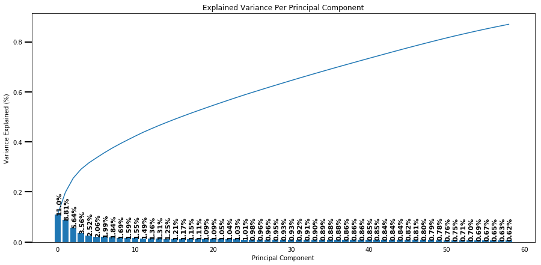

```python
# Investigate the variance accounted for by each principal component.
num_components = len(pca.explained_variance_ratio_)
ind = np.arange(num_components)
vals = pca.explained_variance_ratio_

plt.figure(figsize=(15, 7))
ax = plt.subplot(111)
cumvals = np.cumsum(vals)
ax.bar(ind, vals)
ax.plot(ind, cumvals)
for i in range(num_components):
    ax.annotate(r"%s%%" % ((str(vals[i]*100)[:4])), (ind[i]+0.2, vals[i]), va="bottom", ha="center", rotation=90, fontsize=11, fontweight='bold')

ax.xaxis.set_tick_params(width=0)
ax.yaxis.set_tick_params(width=2, length=12)
ax.set_xlabel("Principal Component")
ax.set_ylabel("Variance Explained (%)")
plt.title('Explained Variance Per Principal Component');
```

```python
# Re-apply PCA to the data while selecting for number of components to retain.
pca = PCA(23)
azdias_pca = pca.fit_transform(azdias_clean_scaled)
```

```python
print("The total variance explained by the 23 extracted features is {:.1f}%.".format(pca.explained_variance_ratio_.sum()*100))
```

```
The total variance explained by the 23 extracted features is 56.4%.
```

### Discussion 2.2: Perform Dimensionality Reduction

I first applied Principal Component Analysis to the data for N(columns)/2 components, to significantly reduce features. I then compared the variance explained by the extracted features to the cumulative variance explained by the number of features. I then decided to keep 23 features, as I wanted each feature to have a ratio of more than 1% variance explained, and the whole set of features to explain more than half of the variance in the dataset.

### Step 2.3: Interpret Principal Components

Now that we have our transformed principal components, it's a nice idea to check out the weight of each variable on the first few components to see if they can be interpreted in some fashion.

As a reminder, each principal component is a unit vector that points in the direction of highest variance (after accounting for the variance captured by earlier principal components). The further a weight is from zero, the more the principal component is in the direction of the corresponding feature. If two features have large weights of the same sign (both positive or both negative), then increases in one tend expect to be associated with increases in the other. To contrast, features with different signs can be expected to show a negative correlation: increases in one variable should result in a decrease in the other.

- To investigate the features, you should map each weight to their corresponding feature name, then sort the features according to weight. The most interesting features for each principal component, then, will be those at the beginning and end of the sorted list. Use the data dictionary document to help you understand these most prominent features, their relationships, and what a positive or negative value on the principal component might indicate.
- You should investigate and interpret feature associations from the first three principal components in this substep. To help facilitate this, you should write a function that you can call at any time to print the sorted list of feature weights, for the *i*-th principal component. This might come in handy in the next step of the project, when you interpret the tendencies of the discovered clusters.

```python
# Map weights for the first principal component to corresponding feature names
# and then print the linked values, sorted by weight.
# HINT: Try defining a function here or in a new cell that you can reuse in the
# other cells.

def component_weights(pca, i):
    comp_df = pd.DataFrame(pca.components_, columns=list(azdias_clean_scaled.columns))
    sorted_df = comp_df.iloc[i].sort_values(ascending=False)
    return sorted_df
```

```python
pc_0 = component_weights(pca, 0)
print(pc_0)
```

```
LP_STATUS_GROB_1.0       0.200756
HH_EINKOMMEN_SCORE       0.185709
PLZ8_ANTG3               0.184979
PLZ8_ANTG4               0.179874
WEALTH                   0.174880
FINANZ_SPARER            0.162628
ORTSGR_KLS9              0.159832
EWDICHTE                 0.158408
FINANZTYP_1              0.144454
FINANZ_HAUSBAUER         0.142126
KBA05_ANTG4              0.131176
SEMIO_PFLICHT            0.126893
PLZ8_ANTG2               0.126528
DECADE                   0.124455
SEMIO_REL                0.122459
KBA05_ANTG3              0.119347
ANZ_HAUSHALTE_AKTIV      0.116648
ARBEIT                   0.114049
RELAT_AB                 0.108613
SEMIO_RAT                0.106321
SEMIO_TRADV              0.101825
ZABEOTYP_5               0.096638
FINANZ_UNAUFFAELLIGER    0.094526
FINANZ_ANLEGER           0.093483
SEMIO_MAT                0.081266
SEMIO_FAM                0.077363
LP_FAMILIE_GROB_1.0      0.075795
SEMIO_KULT               0.075469
GEBAEUDETYP_3.0          0.070799
GFK_URLAUBERTYP_12.0     0.067750
                           ...
ZABEOTYP_3              -0.048590
GFK_URLAUBERTYP_7.0     -0.050077
LP_FAMILIE_GROB_5.0     -0.057517
KBA13_ANZAHL_PKW        -0.061391
WOHNDAUER_2008          -0.063197
CJT_GESAMTTYP_2.0       -0.067112
ANZ_PERSONEN            -0.072864
SEMIO_ERL               -0.081472
SEMIO_LUST              -0.082314
NATIONALITAET_KZ_1.0    -0.084630
ZABEOTYP_1              -0.091630
GEBAEUDETYP_1.0         -0.093396
FINANZTYP_2             -0.100662
GEBAEUDETYP_RASTER      -0.101042
BALLRAUM                -0.102363
GREEN_AVANTGARDE        -0.105668
MOVEMENT                -0.105668
LIFE_STAGE              -0.111006
LP_STATUS_GROB_4.0      -0.116402
LP_STATUS_GROB_5.0      -0.118863
FINANZ_VORSORGER        -0.129042
ALTERSKATEGORIE_GROB    -0.132055
INNENSTADT              -0.132919
PLZ8_GBZ                -0.135244
KONSUMNAEHE             -0.139600
KBA05_GBZ               -0.183904
PLZ8_ANTG1              -0.185429
KBA05_ANTG1             -0.192173
MOBI_REGIO              -0.208025
FINANZ_MINIMALIST       -0.218895
Name: 0, Length: 118, dtype: float64
```

```python
# Map weights for the second principal component to corresponding feature names
# and then print the linked values, sorted by weight.
pc_1 = component_weights(pca, 1)
print(pc_1)
```

```
ALTERSKATEGORIE_GROB     0.216399
ZABEOTYP_3               0.201900
FINANZ_VORSORGER         0.201811
SEMIO_ERL                0.182408
SEMIO_LUST               0.154159
RETOURTYP_BK_S           0.151395
W_KEIT_KIND_HH           0.130285
FINANZ_HAUSBAUER         0.128890
PLZ8_ANTG3               0.108720
PLZ8_ANTG4               0.104274
EWDICHTE                 0.102527
ORTSGR_KLS9              0.101836
CJT_GESAMTTYP_2.0        0.100795
FINANZTYP_5              0.095892
WEALTH                   0.094824
SEMIO_KRIT               0.088845
KBA05_ANTG4              0.084884
SEMIO_KAEM               0.084097
HH_EINKOMMEN_SCORE       0.082507
ARBEIT                   0.077357
ANZ_HAUSHALTE_AKTIV      0.075658
FINANZTYP_2              0.075569
PLZ8_ANTG2               0.074823
RELAT_AB                 0.072825
SHOPPER_TYP_3.0          0.071101
LP_FAMILIE_GROB_1.0      0.070861
CJT_GESAMTTYP_1.0        0.067109
LP_STATUS_GROB_1.0       0.066638
GFK_URLAUBERTYP_4.0      0.062471
FINANZTYP_6              0.061314
                           ...
BALLRAUM                -0.066252
SEMIO_SOZ               -0.069824
LP_FAMILIE_GROB_4.0     -0.070767
GFK_URLAUBERTYP_9.0     -0.070901
ZABEOTYP_5              -0.074358
ANZ_PERSONEN            -0.077974
PLZ8_GBZ                -0.083028
INNENSTADT              -0.083207
KONSUMNAEHE             -0.083859
ZABEOTYP_1              -0.088037
FINANZTYP_4             -0.091074
FINANZTYP_3             -0.091626
ZABEOTYP_4              -0.093882
KBA05_ANTG1             -0.097672
FINANZTYP_1             -0.100249
KBA05_GBZ               -0.105509
PLZ8_ANTG1              -0.107880
MOBI_REGIO              -0.111740
SEMIO_MAT               -0.126097
SEMIO_FAM               -0.137638
SEMIO_RAT               -0.147492
SEMIO_KULT              -0.169770
ONLINE_AFFINITAET       -0.171797
FINANZ_ANLEGER          -0.184405
SEMIO_PFLICHT           -0.188800
SEMIO_TRADV             -0.197454
FINANZ_SPARER           -0.199837
FINANZ_UNAUFFAELLIGER   -0.204261
SEMIO_REL               -0.205127
DECADE                  -0.212718
Name: 1, Length: 118, dtype: float64
```

```python
# Map weights for the third principal component to corresponding feature names
# and then print the linked values, sorted by weight.
pc_2 = component_weights(pca, 2)
print(pc_2)
```

```
SEMIO_VERT               0.324189
SEMIO_SOZ                0.258102
SEMIO_FAM                0.258054
SEMIO_KULT               0.246745
FINANZTYP_5              0.140162
FINANZ_MINIMALIST        0.128580
SHOPPER_TYP_0.0          0.125223
ZABEOTYP_1               0.106141
SEMIO_REL                0.101077
RETOURTYP_BK_S           0.086664
W_KEIT_KIND_HH           0.082771
SEMIO_MAT                0.080330
FINANZ_VORSORGER         0.065490
ORTSGR_KLS9              0.058129
EWDICHTE                 0.057925
SHOPPER_TYP_1.0          0.053702
PLZ8_ANTG4               0.052922
PLZ8_ANTG3               0.052806
ZABEOTYP_6               0.052718
GREEN_AVANTGARDE         0.051555
MOVEMENT                 0.051555
ARBEIT                   0.037306
PLZ8_ANTG2               0.037001
RELAT_AB                 0.035899
SEMIO_LUST               0.034504
ALTERSKATEGORIE_GROB     0.034147
GFK_URLAUBERTYP_4.0      0.034121
LP_STATUS_GROB_5.0       0.032682
KBA05_ANTG4              0.031544
GEBAEUDETYP_3.0          0.030936
                           ...
GEBAEUDETYP_1.0         -0.031794
GFK_URLAUBERTYP_9.0     -0.033161
NATIONALITAET_KZ_3.0    -0.033462
CJT_GESAMTTYP_6.0       -0.035530
SEMIO_TRADV             -0.035741
MOBI_REGIO              -0.035861
ONLINE_AFFINITAET       -0.039324
SEMIO_PFLICHT           -0.040535
PLZ8_GBZ                -0.040960
GEBAEUDETYP_RASTER      -0.041176
FINANZ_HAUSBAUER        -0.041826
BALLRAUM                -0.044769
KONSUMNAEHE             -0.048273
LP_FAMILIE_GROB_3.0     -0.050720
SHOPPER_TYP_3.0         -0.051230
INNENSTADT              -0.052695
PLZ8_ANTG1              -0.052997
FINANZ_UNAUFFAELLIGER   -0.067257
ZABEOTYP_4              -0.069151
FINANZ_SPARER           -0.070697
DECADE                  -0.074446
SHOPPER_TYP_2.0         -0.095156
FINANZTYP_1             -0.106597
FINANZ_ANLEGER          -0.161551
SEMIO_RAT               -0.172707
SEMIO_ERL               -0.199151
SEMIO_KRIT              -0.269298
SEMIO_DOM               -0.294686
SEMIO_KAEM              -0.322169
GENDER                  -0.351197
Name: 2, Length: 118, dtype: float64
```

### Discussion 2.3: Interpret Principal Components

**The First Component:**

- *Income & Finance:* The two features with the highest positive weights are LP_STATUS_1.0, which is a dummy created from the category of "low-income earners" and HH_EINKOMMEN_SCORE, in which a higher score means lower income. The fifth highest positive weight, "WEALTH" is similarily coded, meaning that a higher value represents less affluent individuals. The lowest negative weight is, accordingly "FINANZ_MINIMALIST" (again, for this typology, higher values mean the type does not correspond well to an individual's financial behavior). It seems that, from an income and finance perspective, this component shows the relationship between the features low-income and low financial interest.
- *Location & Surroundings:* The third and fourth highest positive weights are 'PLZ-8_ANTG3' and 'PLZ-8_ANTG4', which both account for a higher share of 6-8 and of 10+ family houses in the surroundings, respectively. Accordingly, the three and fifth lowest negative weights show that there is a lower number of 1-2 family houses, as well as a lower number of buildings in the direct neighborhood, whereas 'PLZ-8-ANTG1' shows a lower share of 1-2 family houses in the greater area. The second lowest negative weight, 'MOBI_REGIO', shows a higher movement pattern.
- The first component seems to account for the income / residence relationship, whereas a low income is related to living in smaller apartments where more families fit in one building, so to say.

**The Second Component:**

- *Personal Features:* The highest positive weight is on "ALTERSKATEGORIE_GROB", in which a higher number stands for a higher age, which fits to the lowest negative weight on "DECADE", in which a lower value stands for an earlier decade. Another interesting set of features in the top weights is the features from the "SEMIO"-personality typology. Here, low values actually mean a high affinity for this tyology. On the positive side, we have event-oriented and sensual-minded, whereas on the negative side, we find religious, traditional and dutiful.
- *Financial and Shopping behavior:* The second highest positive weight is "ZABEOTYP_3", the "fair supplied" energy consumption type. As for the finance types, there is a high positive weight on the "be prepared" type (which means the typology is not applicable), whereas the types "inconspicuous", "money saver" and "investor" seem to be more applicable here. Interestingly, one of the high positive factors is "RETOURTYP_BK_S", which indicates being less prone to return orders.
- To summarize, the second component might represent the relationship between age and more traditional values and financial behavior.

**The Third Component:**

- *Personality Features:* Surprisingly, the top weights of the third component are mainly composed of the personality typology "SEMIO"-features. On the positive side, there is dreamful, socially-minded, family-minded and cultural-minded, whereas on the negative side, there are the types combative attitude, dominant, critical-minded, event-oriented and rational.
- Additional features are "FINANZTYP-5" (investor) on the positive side, and "GENDER" as the most dominant negative weight (-0.35).
- The third component probably accounts for the relationship between gender and "typical" gender-related personality types (dominant, combative men and social-minded, cultural-minded women), as well as for the possibly adverse relationship between event-orientation and the inclination to make longer-term financial investments.

## Step 3: Clustering

### Step 3.1: Apply Clustering to General Population

You've assessed and cleaned the demographics data, then scaled and transformed them. Now, it's time to see how the data clusters in the principal components space. In this substep, you will apply k-means clustering to the dataset and use the average within-cluster distances from each point to their assigned cluster's centroid to decide on a number of clusters to keep.

- Use sklearn's KMeans class to perform k-means clustering on the PCA-transformed data.
- Then, compute the average difference from each point to its assigned cluster's center. **Hint**: The KMeans object's `.score()` method might be useful here, but note that in sklearn, scores tend to be defined so that larger is better. Try applying it to a small, toy dataset, or use an internet search to help your understanding.
- Perform the above two steps for a number of different cluster counts. You can then see how the average distance decreases with an increasing number of clusters. However, each additional cluster provides a smaller net benefit. Use this fact to select a final number of clusters in which to group the data. **Warning**: because of the large size of the dataset, it can take a long time for the algorithm to resolve. The more clusters to fit, the longer the algorithm will take. You should test for cluster counts through at least 10 clusters to get the full picture, but you shouldn't need to test for a number of clusters above about 30.
- Once you've selected a final number of clusters to use, re-fit a KMeans instance to perform the clustering operation. Make sure that you also obtain the cluster assignments for the general demographics data, since you'll be using them in the final Step 3.3.

```python
# Over a number of different cluster counts...
centers = list(range(1,15))
# run k-means clustering on the data and...
# compute the average within-cluster distances.
scores = []

for k in centers:
    kmeans = KMeans(k)
    model = kmeans.fit(azdias_pca)
    scores.append(abs((model.score(azdias_pca))))
print(scores)
```

```
[53094849.794152714, 45353786.835089855, 41071483.411370352, 38522370.690131746, 36929000.721138589, 35507772.735653184, 34224218.59908095, 33170964.298920125, 32438252.388008617, 31801805.824789677, 31235804.741756875, 30781917.521124419, 30367219.180728212, 29990659.622527517]
```

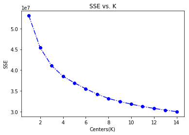

```python
# Investigate the change in within-cluster distance across number of clusters.
# HINT: Use matplotlib's plot function to visualize this relationship.
plt.plot(centers, scores, linestyle='-.', marker='o', color='b')
plt.xlabel('Centers(K)')
plt.ylabel('SSE')
plt.title('SSE vs. K');
```

```python
# Re-fit the k-means model with the selected number of clusters and obtain
# cluster predictions for the general population demographics data.
#input Cluster value
k=7
kmeans = KMeans(k)
kmodel = kmeans.fit(azdias_pca)
azdias_labels = kmodel.predict(azdias_pca)
```

### Discussion 3.1: Apply Clustering to General Population

Looking at the plot above, as expected, there is a gradual decrease in the score, but no obvious "elbow". In my impression, the slope becomes less steep after K=7, so I chose 7 as the number of clusters.

### Step 3.2: Apply All Steps to the Customer Data

Now that you have clusters and cluster centers for the general population, it's time to see how the customer data maps on to those clusters. Take care to not confuse this for re-fitting all of the models to the customer data. Instead, you're going to use the fits from the general population to clean, transform, and cluster the customer data. In the last step of the project, you will interpret how the general population fits apply to the customer data.

- Don't forget when loading in the customers data, that it is semicolon (`;`) delimited.
- Apply the same feature wrangling, selection, and engineering steps to the customer demographics using the `clean_data()` function you created earlier. (You can assume that the customer demographics data has similar meaning behind missing data patterns as the general demographics data.)
- Use the sklearn objects from the general demographics data, and apply their transformations to the customers data. That is, you should not be using a `.fit()` or `.fit_transform()` method to re-fit the old objects, nor should you be creating new sklearn objects! Carry the data through the feature scaling, PCA, and clustering steps, obtaining cluster assignments for all of the data in the customer demographics data.

```python
# Load in the customer demographics data.
customers = pd.read_csv('Udacity_CUSTOMERS_Subset.csv', sep=';')
```

```python
# Apply preprocessing, feature transformation, and clustering from the general
# demographics onto the customer data, obtaining cluster predictions for the
# customer demographics data.
customers_clean = clean_data(customers)
```

```python
customers_clean.shape
```

```
(141771, 117)
```

117 is one column short in comparision to the General Population data. My hypothesis is that one categorical value was erased before being turned into a dummy.

```python
#Check for columns that have ben missed in one-hot encoding
col_list_customers = list(customers_clean.columns)
col_list_azdias = list(azdias_clean.columns)
missing_cols = []
for e in col_list_azdias:
    if e not in col_list_customers:
        missing_cols.append(e)
print(missing_cols)
```

```
['GEBAEUDETYP_5.0']
```

```python
# I will check if the value 5 was present in the original customers dataset
customers.GEBAEUDETYP.unique()
```

```
array([  1.,  nan,   8.,   2.,   3.,   4.,   6.])
```

```python
#Apparently the value 5 wasn't in the original dataset either. In order to fit my models,
# I will create a dummy row with that title and the value 0
customers_clean['GEBAEUDETYP_5.0'] = 0
customers_clean.shape
```

```
(141771, 118)
```

```python
#Check if it worked
col_list_customers = list(customers_clean.columns)
col_list_azdias = list(azdias_clean.columns)
missing_cols = []
for e in col_list_azdias:
    if e not in col_list_customers:
        missing_cols.append(e)
print(missing_cols)
```

```
[]
```

```python
#Imputing
customers_clean_nums = customers_clean[nan_nums]
customers_clean_nums_imputed = pd.DataFrame(fill_missing_median.transform(customers_clean_nums))
customers_clean_nums_imputed.columns = customers_clean_nums.columns
customers_clean_nums_imputed.index = customers_clean_nums.index

customers_clean_cats = customers_clean.drop(nan_nums, axis=1)
fill_missing = Imputer(strategy='most_frequent')
customers_clean_cats_imputed = pd.DataFrame(fill_missing_m_frequent.transform(customers_clean_cats))
customers_clean_cats_imputed.columns = customers_clean_cats.columns
customers_clean_cats_imputed.index = customers_clean_cats.index

customers_clean_imputed = customers_clean_cats_imputed.join(customers_clean_nums_imputed)
```

```python
#Scaling
customers_clean_scaled = scaler.transform(customers_clean_imputed)
customers_clean_scaled = pd.DataFrame(customers_clean_scaled)
customers_clean_scaled.columns = customers_clean_imputed.columns
customers_clean_scaled.head()
```

|  | GENDER | FINANZ_MINIMALIST | FINANZ_SPARER | FINANZ_VORSORGER | FINANZ_ANLEGER | FINANZ_UNAUFFAELLIGER | FINANZ_HAUSBAUER | GREEN_AVANTGARDE | SEMIO_SOZ | SEMIO_FAM | SEMIO_REL | SEMIO_MAT | SEMIO_VERT | SEMIO_LUST | SEMIO_ERL | SEMIO_KULT | SEMIO_RAT | SEMIO_KRIT | SEMIO_DOM | SEMIO_KAEM | SEMIO_PFLICHT | SEMIO_TRADV | SOHO_KZ | VERS_TYP | ANZ_PERSONEN | ANZ_TITEL | HH_EINKOMMEN_SCORE | WOHNDAUER_2008 | MIN_GEBAEUDEJAHR | … |
| --- | --- | --- | --- | --- | --- | --- | --- | --- | --- | --- | --- | --- | --- | --- | --- | --- | --- | --- | --- | --- | --- | --- | --- | --- | --- | --- | --- | --- | --- | --- |
| 0 | -1.043935 | 1.409057 | -1.155518 | 1.138172 | -1.249985 | -0.470407 | -0.791205 | 1.885336 | 0.958417 | 0.463193 | -1.044002 | 1.104148 | 0.885415 | 1.268015 | -0.887967 | -0.067380 | -1.750689 | -0.880254 | -1.946340 | -1.763868 | -1.178347 | -1.543006 | -0.092131 | -1.083489 | 0.234451 | -0.060408 | -2.209018 | 0.567325 | -0.38317 | … |
| 1 | 0.957914 | 1.409057 | -1.155518 | 1.138172 | -1.249985 | 0.958645 | 0.629141 | 1.885336 | -1.102454 | -1.104443 | -1.567425 | -0.463904 | -0.656542 | 1.268015 | 1.301667 | -1.599742 | -1.145714 | 1.392000 | 0.244059 | 0.913308 | -0.099530 | -1.543006 | -0.092131 | 0.922944 | -0.630205 | -0.060408 | -2.209018 | 0.567325 | -0.38317 | … |
| 2 | -1.043935 | 1.409057 | -1.155518 | 1.138172 | -0.570998 | -1.184933 | -0.791205 | -0.530409 | 0.958417 | 0.463193 | -0.520579 | 0.058780 | 1.399401 | 0.316846 | -0.887967 | -0.067380 | -0.540740 | -0.880254 | -0.851141 | -0.692998 | -0.638939 | 0.156187 | -0.092131 | -1.083489 | -1.494862 | -0.060408 | -0.267579 | 0.567325 | -0.38317 | … |
| 3 | -1.043935 | -0.042768 | -1.155518 | 0.411884 | 0.786978 | 1.673172 | -0.791205 | -0.530409 | -0.072018 | 0.463193 | 0.002844 | 1.104148 | 0.371430 | 0.792431 | -0.340559 | 0.443408 | 0.669208 | -0.880254 | 0.244059 | -1.228433 | 0.439878 | 0.156187 | -0.092131 | 0.922944 | 1.963765 | -0.060408 | 1.026714 | 0.567325 | -0.38317 | … |
| 4 | -1.043935 | 1.409057 | -1.155518 | 1.138172 | -1.249985 | -0.470407 | -0.081032 | 1.885336 | 0.958417 | -0.059352 | 0.002844 | -1.509273 | 1.399401 | 0.792431 | -0.340559 | 0.954195 | -1.145714 | 0.255873 | 0.244059 | -0.692998 | -0.638939 | 0.156187 | -0.092131 | 0.922944 | 0.234451 | -0.060408 | -2.209018 | 0.567325 | -0.38317 | … |

```python
#PCA
customers_pca = pca.transform(customers_clean_scaled)
```

```python
#Clustering
customers_labels = kmodel.predict(customers_pca)
```

### Step 3.3: Compare Customer Data to Demographics Data

At this point, you have clustered data based on demographics of the general population of Germany, and seen how the customer data for a mail-order sales company maps onto those demographic clusters. In this final substep, you will compare the two cluster distributions to see where the strongest customer base for the company is.

Consider the proportion of persons in each cluster for the general population, and the proportions for the customers. If we think the company's customer base to be universal, then the cluster assignment proportions should be fairly similar between the two. If there are only particular segments of the population that are interested in the company's products, then we should see a mismatch from one to the other. If there is a higher proportion of persons in a cluster for the customer data compared to the general population (e.g. 5% of persons are assigned to a cluster for the general population, but 15% of the customer data is closest to that cluster's centroid) then that suggests the people in that cluster to be a target audience for the company. On the other hand, the proportion of the data in a cluster being larger in the general population than the customer data (e.g. only 2% of customers closest to a population centroid that captures 6% of the data) suggests that group of persons to be outside of the target demographics.

Take a look at the following points in this step:

- Compute the proportion of data points in each cluster for the general population and the customer data. Visualizations will be useful here: both for the individual dataset proportions, but also to visualize the ratios in cluster representation between groups. Seaborn's [`countplot()`](https://seaborn.pydata.org/generated/seaborn.countplot.html) or [`barplot()`](https://seaborn.pydata.org/generated/seaborn.barplot.html) function could be handy.
  - Recall the analysis you performed in step 1.1.3 of the project, where you separated out certain data points from the dataset if they had more than a specified threshold of missing values. If you found that this group was qualitatively different from the main bulk of the data, you should treat this as an additional data cluster in this analysis. Make sure that you account for the number of data points in this subset, for both the general population and customer datasets, when making your computations!
- Which cluster or clusters are overrepresented in the customer dataset compared to the general population? Select at least one such cluster and infer what kind of people might be represented by that cluster. Use the principal component interpretations from step 2.3 or look at additional components to help you make this inference. Alternatively, you can use the `.inverse_transform()` method of the PCA and StandardScaler objects to transform centroids back to the original data space and interpret the retrieved values directly.
- Perform a similar investigation for the underrepresented clusters. Which cluster or clusters are underrepresented in the customer dataset compared to the general population, and what kinds of people are typified by these clusters?

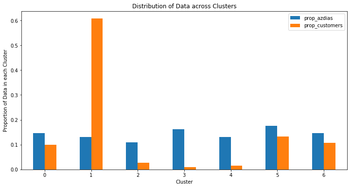

```python
# Compare the proportion of data in each cluster for the customer data to the
# proportion of data in each cluster for the general population.

azdias_prop = []
customers_prop = []
x = list(range(7))
for i in range(7):
    azdias_prop.append((azdias_labels == i).sum()/len(azdias_labels))
    customers_prop.append((customers_labels == i).sum()/len(customers_labels))


prop_all = pd.DataFrame({'cluster' : x, 'prop_azdias' : azdias_prop, 'prop_customers':customers_prop})

#ax = sns.countplot(x='index', y = df_general['prop_1', 'prop_2'], data=df_general )
prop_all.plot(x='cluster', y = ['prop_azdias', 'prop_customers'], kind='bar', figsize=(12,6), rot=0)
plt.title('Distribution of Data across Clusters')
plt.ylabel('Proportion of Data in each Cluster')
plt.xlabel('Cluster')
plt.show()
```

```python
#For an overview of the clusters, I will check for the values in the theoretical cluster center
cluster_summary = pd.DataFrame(scaler.inverse_transform(pca.inverse_transform(kmodel.cluster_centers_)), columns=customers_clean_scaled.columns)
cluster_summary
```

|  | GENDER | FINANZ_MINIMALIST | FINANZ_SPARER | FINANZ_VORSORGER | FINANZ_ANLEGER | FINANZ_UNAUFFAELLIGER | FINANZ_HAUSBAUER | GREEN_AVANTGARDE | SEMIO_SOZ | SEMIO_FAM | SEMIO_REL | SEMIO_MAT | SEMIO_VERT | SEMIO_LUST | SEMIO_ERL | SEMIO_KULT | SEMIO_RAT | SEMIO_KRIT | SEMIO_DOM | SEMIO_KAEM | SEMIO_PFLICHT | SEMIO_TRADV | SOHO_KZ | VERS_TYP | ANZ_PERSONEN | ANZ_TITEL | HH_EINKOMMEN_SCORE | WOHNDAUER_2008 | MIN_GEBAEUDEJAHR | … |
| --- | --- | --- | --- | --- | --- | --- | --- | --- | --- | --- | --- | --- | --- | --- | --- | --- | --- | --- | --- | --- | --- | --- | --- | --- | --- | --- | --- | --- | --- | --- |
| 0 | 0.948182 | 2.591988 | 1.895271 | 4.260571 | 2.249464 | 1.736694 | 4.263632 | 0.069270 | 2.867224 | 2.269637 | 2.082759 | 2.709036 | 2.797717 | 5.486284 | 6.564737 | 1.953877 | 3.389254 | 5.950192 | 5.838473 | 5.998526 | 2.892713 | 2.421567 | 0.008328 | 0.592407 | 1.385232 | 0.006232 | 5.368477 | 8.119145 | 1992.437409 | … |
| 1 | 0.504601 | 4.536368 | 1.620436 | 4.242273 | 1.808287 | 2.158593 | 2.100153 | 0.978804 | 4.107170 | 3.419898 | 2.926126 | 3.026551 | 4.693309 | 5.296213 | 5.210541 | 3.448562 | 3.110084 | 4.359720 | 4.671528 | 4.256119 | 3.164840 | 3.007625 | 0.008961 | 0.516580 | 2.278086 | 0.006623 | 2.317509 | 8.745027 | 1993.012743 | … |
| 2 | -0.035646 | 3.163492 | 3.916512 | 2.196498 | 3.633277 | 3.944766 | 2.194668 | 0.301755 | 5.978531 | 6.420292 | 6.017912 | 5.286931 | 6.315144 | 3.306438 | 2.442405 | 6.611467 | 4.077180 | 2.740825 | 2.694182 | 2.056537 | 5.328678 | 4.859373 | 0.012823 | 0.453579 | 2.018461 | 0.006863 | 3.858074 | 7.470977 | 1994.256878 | … |
| 3 | 0.612735 | 1.285034 | 4.468302 | 2.097144 | 4.029264 | 3.844730 | 4.050729 | 0.042118 | 4.543607 | 4.975507 | 5.679546 | 4.786811 | 3.607009 | 3.083509 | 3.565559 | 5.087784 | 5.256197 | 4.519912 | 4.874520 | 4.773875 | 5.925313 | 5.099795 | 0.007154 | 0.592587 | 1.440263 | -0.001250 | 5.659630 | 7.120325 | 1992.649891 | … |
| 4 | 0.980170 | 2.276363 | 3.899888 | 2.341077 | 4.322200 | 3.895943 | 2.888426 | 0.198273 | 2.908627 | 3.481501 | 4.776033 | 4.519317 | 2.628931 | 3.095850 | 4.593021 | 3.714667 | 5.746008 | 5.537944 | 5.944083 | 5.626987 | 5.604664 | 5.262041 | 0.007936 | 0.430491 | 1.929639 | 0.003718 | 4.097606 | 7.538827 | 1994.154729 | … |
| 5 | 0.484391 | 4.291459 | 1.624502 | 4.270465 | 2.420671 | 1.791465 | 2.395419 | 0.007033 | 3.749963 | 3.472691 | 2.972925 | 3.033813 | 4.522627 | 4.912459 | 5.315573 | 3.545741 | 3.053354 | 4.640536 | 4.210975 | 3.951049 | 3.175054 | 2.779828 | 0.007210 | 0.521703 | 1.842005 | 0.001252 | 3.870168 | 8.164509 | 1993.990260 | … |
| 6 | 0.054754 | 3.308228 | 1.936445 | 4.250831 | 1.625768 | 1.690072 | 3.587013 | 0.102083 | 5.206121 | 5.252480 | 4.023769 | 4.263570 | 5.800563 | 4.882740 | 4.131149 | 5.104213 | 2.803305 | 3.696285 | 3.356909 | 2.970474 | 3.552115 | 3.058724 | 0.008025 | 0.635177 | 1.368578 | 0.007784 | 5.304894 | 8.174730 | 1992.667682 | … |

```python
cluster_1 = scaler.inverse_transform(pca.inverse_transform(kmodel.cluster_centers_[1]))
```

```python
cluster_2 = scaler.inverse_transform(pca.inverse_transform(kmodel.cluster_centers_[3]))
```

```python
pd.set_option('display.max_rows', None)
cluster_summary = pd.DataFrame({"feature":customers_clean_scaled.columns,"overrepresented":cluster_1,"underrepresented":cluster_2})
print(cluster_summary.round(decimals=2))
```

```
                   feature  overrepresented  underrepresented
0                   GENDER             0.50              0.61
1        FINANZ_MINIMALIST             4.54              1.29
2            FINANZ_SPARER             1.62              4.47
3         FINANZ_VORSORGER             4.24              2.10
4           FINANZ_ANLEGER             1.81              4.03
5    FINANZ_UNAUFFAELLIGER             2.16              3.84
6         FINANZ_HAUSBAUER             2.10              4.05
7         GREEN_AVANTGARDE             0.98              0.04
8                SEMIO_SOZ             4.11              4.54
9                SEMIO_FAM             3.42              4.98
10               SEMIO_REL             2.93              5.68
11               SEMIO_MAT             3.03              4.79
12              SEMIO_VERT             4.69              3.61
13              SEMIO_LUST             5.30              3.08
```

[output cut: 104 more lines]

> Congratulations on making it this far in the project! Before you finish, make sure to check through the entire notebook from top to bottom to make sure that your analysis follows a logical flow and all of your findings are documented in **Discussion** cells. Once you've checked over all of your work, you should export the notebook as an HTML document to submit for evaluation. You can do this from the menu, navigating to **File -> Download as -> HTML (.html)**. You will submit both that document and this notebook for your project submission.